# Data Science for Veterinary Undergraduate Students

### Figure

First we need to exclude the animals with no gait score, so let’s create a new data frame specifically for this plot:

```r
topic_3_solution |>
  filter(!is.na(GaitScore)) ->
  plotdata
```

We want a boxplot, so we can start with some code we were given to produce a boxplot i.e.:

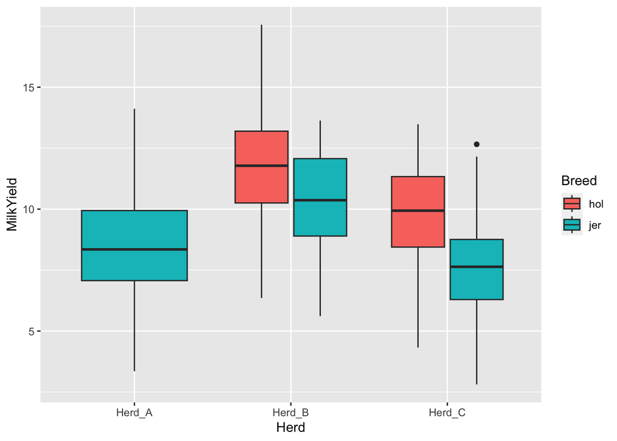

```r
ggplot(topic_3_solution, aes(x=Herd, y=MilkYield, fill=Breed)) +
  geom_boxplot()
```

All we need to do is change the data, what is on the x axis, remove the unnecessary fill colour, and then add a facet_wrap by Herd (using more code that we copy/pasted):

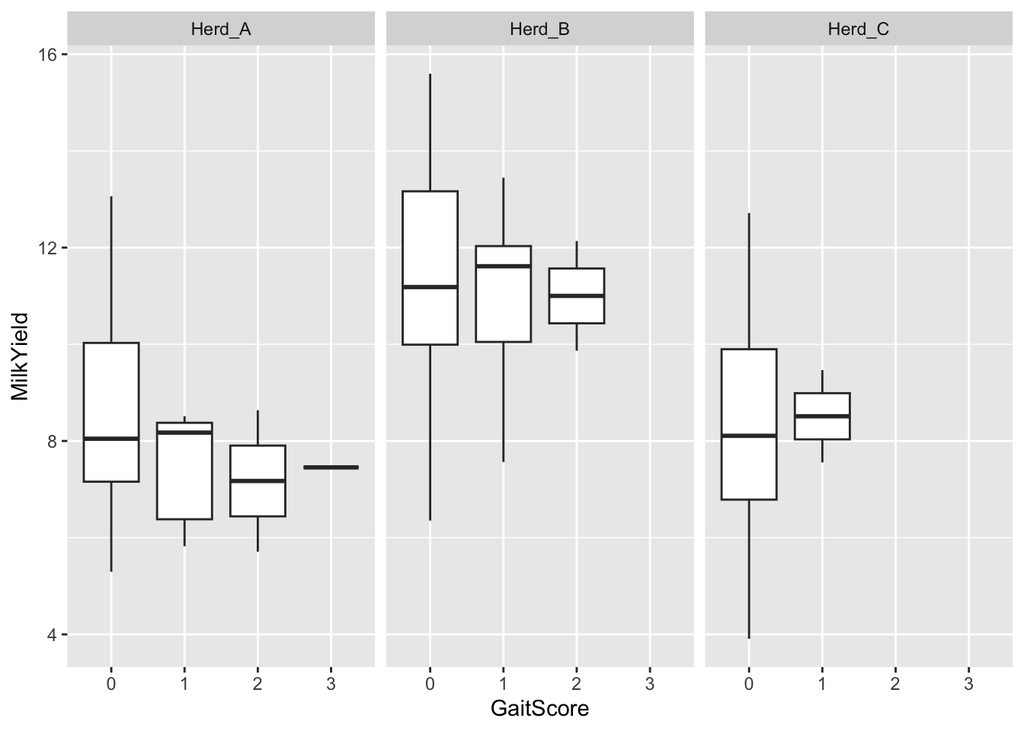

```r
ggplot(plotdata, aes(x=GaitScore, y=MilkYield)) +
  geom_boxplot() +
  facet_wrap(~Herd)
```

Then we can make some minor modifications:

- We were asked for herds in a single column, so let’s add an ncol=1 argument to facet_wrap
- We were asked for horizontal boxplots rather than the standard vertical, so let’s use coord_flip
- We might want theme_light() for a better publication-quality plot, so let’s add that
- Let’s change the y and x axis labels as well

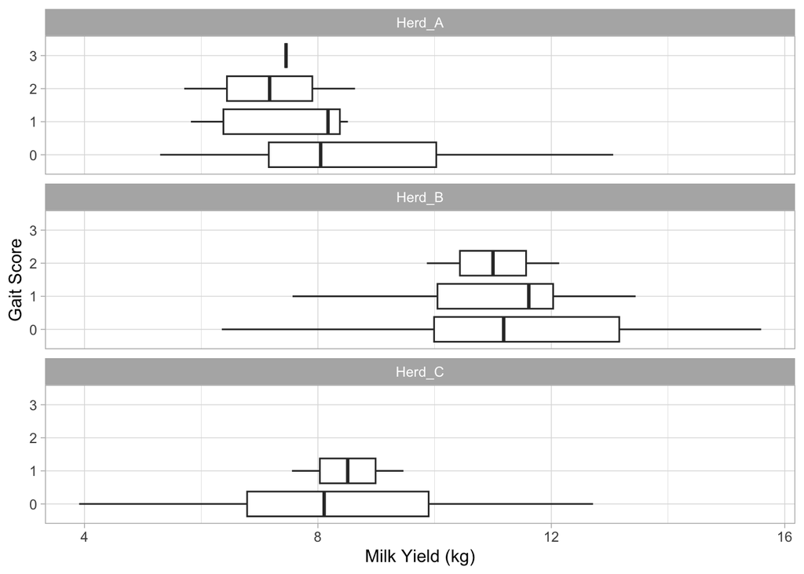

```r
ggplot(plotdata, aes(x=GaitScore, y=MilkYield)) +
  geom_boxplot() +
  facet_wrap(~Herd, ncol=1) +
  coord_flip() +
  xlab("Gait Score") +
  ylab("Milk Yield (kg)") +
  theme_light()
```

Notice that the xlab and ylab refer to the orientation before flipping the axes!

Finally we just need to save the plot as a PDF:

```r
ggsave("figure1.pdf", width=5, height=7)
```

### Conclusions

The key to creating summary statistics in R is to think about it as just another way of combining and summarising data frames. You will use pivot_longer and pivot_wider a lot when creating tables - for more details on advanced use of these functions you can have a look at the [introduction to pivoting](https://cran.r-project.org/web/packages/tidyr/vignettes/pivot.html)

Creation of high-quality figures is a major strength of R - and there are a wide variety of tools available to help you produce just about whatever plot you can think of, including maps in conjunction with the [sf package](https://r-spatial.github.io/sf/). Some of the more advanced features are quite complex, but a good strategy is to build up your knowledge slowly and try not to get overwhelmed by the more complicated things right away. Online guides such as the “Data visualisation” chapter of the [R for Data Science book](https://r4ds.had.co.nz) can be very helpful in building your knowledge and experience.

## Feedback and acknowledgements

If you have any feedback or suggestions on this training material then please consider filling out [our brief survey](https://forms.gle/KDtwsygjJdE2azBk8)

Development of this training material was partly funded by the [Veterinary Online Collection](https://veterinary-online-collection.eu).

[Return to home page](https://www.costmodds.org/teaching/voc_data_science/)